# Demand function herring

Lars Ravn-Jonsen

28 April 2016

## Data

Data from Arnason et al 2000 is updated with Fiskeridirektoratet2006a, Fiskeridirektoratet2006b so the time series is now 1982–2005, i.e. 24 observations. Harvest in ton and value in 1.000 DKK. Price is calculate as value divided by landings, hence price is in 1.000 DKK pr. ton or DKK pr. kg. Nominal price is converted to real price with CPI Statistik2006 with base of 2004 and converted to NOK by exchange rate 100DKK=90.9300NOK (1/6 2004).

```r
setwd("~/Dropbox/Dokumenter/undervisning/R/Sonderborg")
a = read.csv("pris_sild.csv")
a$price = a$price*0.9093 #From DKK to NOK
a
```

```
##    year landing    price
## 1  1982  81.000 3.864613
## 2  1983 172.000 2.204645
## 3  1984 124.000 2.778501
## 4  1985 136.000 2.969786
## 5  1986 150.000 2.248954
## 6  1987 157.000 1.816671
## 7  1988 184.000 1.835043
## 8  1989 171.000 2.018763
## 9  1990 136.000 2.183031
## 10 1991 146.000 2.140883
## 11 1992 156.000 2.175466
## 12 1993 169.000 1.918257
## 13 1994 178.000 1.853415
## 14 1995 191.000 1.463279
## 15 1996 153.009 1.356541
## 16 1997 125.302 1.524046
## 17 1998 139.711 1.558200
## 18 1999 137.578 1.298876
## 19 2000 153.899 1.129468
## 20 2001 141.508 2.220865
## 21 2002 112.582 2.457409
## 22 2003 114.806 1.729254
## 23 2004 136.809 1.521349
## 24 2005 167.450 1.881092
```

## Model

**model(0,0)** $\epsilon_{i}$ assumed NID$(0,\sigma^{2})$

**model(1,0)** $\epsilon_{i}=\phi\epsilon_{i-1}+\nu_{i}$ where $\nu_{i}$ assumed NID$(0,\sigma^{2})$

**model(2,0)** $\epsilon_{i}=\phi_{1}\epsilon_{i-1}+\phi_{2}\epsilon_{i-2}+\nu_{i}$ where $\nu_{i}$ assumed NID$(0,\sigma^{2})$

**model(0,1)** $\epsilon_{i}=\theta\nu_{i-1}+\nu_{i}$ where $\nu_{i}$ assumed NID$(0,\sigma^{2})$

**model(1,1)** $\epsilon_{i}=\phi\epsilon_{i-1}+\theta\nu_{i-1}+\nu_{i}$ where $\nu_{i}$ assumed NID$(0,\sigma^{2})$

**model(0,2)** $\epsilon_{i}=\theta_{1}\nu_{i-1}+\theta_{2}\nu_{i-2}+\nu_{i}$ where $\nu_{i}$ assumed NID$(0,\sigma^{2})$

**model(1,2)** $\epsilon_{i}=\phi\epsilon_{i-1}+\theta_{1}\nu_{i-1}+\theta_{2}\nu_{i-2}+\nu_{i}$ where $\nu_{i}$ assumed NID$(0,\sigma^{2})$

**model(0,3)** $\epsilon_{i}=\theta_{1}\nu_{i-1}+\theta_{2}\nu_{i-2}+\theta_{3}\nu_{i-3}+\nu_{i}$ where $\nu_{i}$ assumed NID$(0,\sigma^{2})$

```r
library(nlme)
arma.0.0 = gls( price ~ landing, data=a, method="ML")
arma.1.0 = gls( price ~ landing, data=a, correlation=corARMA(p=1,q=0),method="ML")
arma.2.0 = gls( price ~ landing, data=a, correlation=corARMA(p=2,q=0),method="ML")
arma.3.0 = gls( price ~ landing, data=a, correlation=corARMA(p=3,q=0),method="ML")
arma.0.1 = gls( price ~ landing, data=a, correlation=corARMA(p=0,q=1),method="ML")
arma.1.1 = gls( price ~ landing, data=a, correlation=corARMA(p=1,q=1),method="ML")
arma.0.2 = gls( price ~ landing, data=a, correlation=corARMA(p=0,q=2),method="ML")
arma.1.2 = gls( price ~ landing, data=a, correlation=corARMA(p=1,q=2),method="ML")
arma.0.3 = gls( price ~ landing, data=a, correlation=corARMA(p=0,q=3),method="ML")
```

```
##             Par   LogLik  Sigma  Lag 1  Lag 2  Lag 3  Lag 4
## Model (0,0)   2 -17.5485 0.5027 0.5832 1.0201 0.7450 0.9012
## Model (1,0)   3 -10.3114 0.3497 1.7281 2.8730 1.1315 0.9655
## Model (0,1)   3  -7.4173 0.2838 1.1686 1.8289 1.1204 0.9438
## Model (2,0)   4 -10.0513 0.3505 1.7435 2.7329 1.0537 0.9333
## Model (1,1)   4  -5.1579 0.2617 1.8248 2.4718 1.2500 0.9732
## Model (0,2)   4  -3.8654 0.2251 1.8856 1.8345 1.3978 1.3758
## Model (1,2)   5  -5.9966 0.3949 0.8986 1.4164 1.0768 1.2005
## Model (0,3)   5  -3.7112 0.2167 1.8340 1.7615 1.4962 1.3892
```

Model (0,0) show autocorrelation for lag 1 and lag 2. In improving this model with one more parameter the model (0,1), in compar with model (1,0), shows the highest likelihood and the smallest $\sigma$. However the model (0,1) still have autocorrelation and the model (1,0) have a negative autocorrelation for lag 2. Improvement of model (1,0) with one more autocorrelation term do not seem to yield a good result. When improving model (0,1) with one more parameter, model (0,2) shows a higher likelihood and lower $\sigma$ than model (1,1), all Durbin-Watson statistics is better for model (0,2) too, hence model (0,2) is preferred for the models with 4 parameters.

There seems to be no gain in adding one more parameter, the best model here is model (0,3), and her the likelihood is only slightly improved. Model (0,2) is accepted as final model.

Parameter estimates for the model (0,2) is:

```r
zz = summary(arma.0.2)$tTable
```

| Parameter | Estimate | Std.error | t-value | p-value |
| --- | --- | --- | --- | --- |
| $\theta_{1}$ | 1.9908 |  |  |  |
| $\theta_{2}$ | 1.0000 |  |  |  |
| $\alpha$ | 4.0104 | 0.2517 | 15.93 | 1.447e-13 |
| $\beta$ | -0.01309 | 0.001223 | -10.70 | 3.473e-10 |

Both parrameters is very significant.

## Conclusion

The price in the future (for time $t+1$) can be predicted by

$E(p_{t+1})=\alpha+\beta h_{t+1}+\theta_{1}\nu_{t}+\theta_{2}\nu_{t-1}$

Where the parameters $\left(\alpha,\beta,\theta_{1},\theta_{2}\right)$ = (4.0104, -0.01309, 1.9908, 1.0000). The formula for the expected price for next year $E(p_{t+1})$ consist of three parts: The first, $\alpha+\beta h_{t+1}$ is a linear function of next years harvest $h_{t+1}$, the next $\theta_{1}\nu_{t}$ is a correction probational to this years error term $\nu_{t}$ and the last, $\theta_{2}\nu_{t-1}$ is a correction probational to last years error term $\nu_{t-1}$. The $\nu_{i}$’s needed for making prediction is estimated (so that $var(\nu)$ is minimize), and are given in the text file price_herring.txt.

```r
a$nu = v0.2
write.table(a, file = "price_herring.txt")
```

## Refferences

Arnason, R., L. K. Sandal, S.I. Steinshamn, N. Vestergaard, S. Argansson and F. Jensen (2000). Comparative evaluation of the cod and herring fisheries in denmark, iceland and norway. I: TemaNord 2000:526. Nordisk Ministerr ̊ad.

Danmarks Statistik (2006). PRIS8: Forbrugerprisindeks, ̊arsgennemsnit (1900=100). Danmarks Statistik. http://www.statistikbanken.dk

Fiskeridirektoratet (2006a). Danske fiskeres fangster fra samtlige farvande fordelt p ̊a arter 1996-2005, Hel fisk i ton. Fiskeridirektoratet. Quoted 20/6 2006. http://webfd.fd.dk/stat/Faste%20tabeller/Landinger-10aar/tab74b.html

Fiskeridirektoratet (2006b). Danske fiskeres fangster fra samtlige far- vande fordelt p ̊a arter 1996-2005, Værdi i 1.000 kr.. Fiskeridirek- toratet. Quoted 20/6 2006. http://webfd.fd.dk/stat/Faste%20tabeller/Landinger-10aar/tab74b.html

## Appendix

Figures of data and model predictions

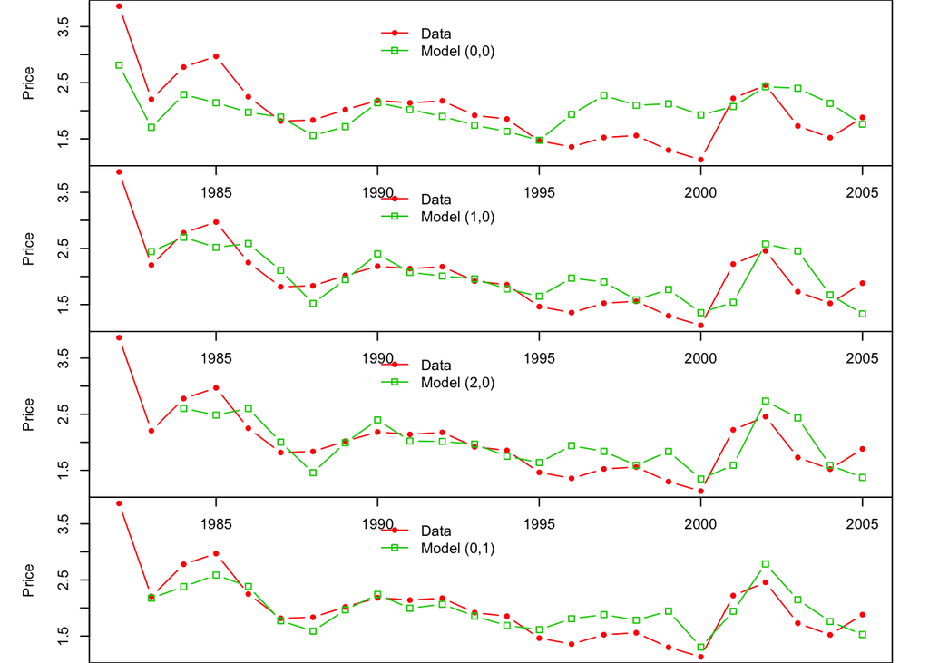

Figures of data and model predictions

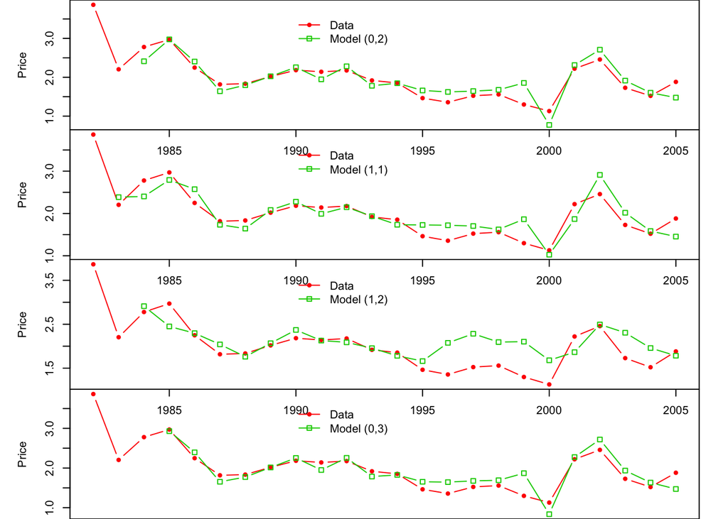

Summary of model (0,2):

```r
summary(arma.0.2)
```

```
## Generalized least squares fit by maximum likelihood
##   Model: price ~ landing
##   Data: a
##        AIC      BIC    logLik
##   17.73089 23.62116 -3.865445
##
## Correlation Structure: ARMA(0,2)
##  Formula: ~1
##  Parameter estimate(s):
##    Theta1    Theta2
## 1.9907796 0.9999801
##
## Coefficients:
##                 Value  Std.Error   t-value p-value
## (Intercept)  4.010429 0.25167877  15.93471       0
## landing     -0.013088 0.00122313 -10.70047       0
##
##  Correlation:
##         (Intr)
## landing -0.656
##
## Standardized residuals:
##         Min          Q1         Med          Q3         Max
## -1.60818836 -1.11326486  0.09143215  0.37655387  1.61419060
##
## Residual standard error: 0.5664258
## Degrees of freedom: 24 total; 22 residual
```